# Project 3

Natalie Pham

```r
library(dplyr)
```

```r
library(ggplot2)
cvg <- read.csv("CVG_Flights.csv", header = TRUE, stringsAsFactors = FALSE, na.strings = "")
d<- as.POSIXct(cvg$FLIGHT_DATE, format = "%m/%d/%Y")
cvg$dm <- format(d, "%m")
```

# CVG data set

## Question 1

What is the departure delay in major airports in each region in the US (West, Midwest, East) - by month

West coast

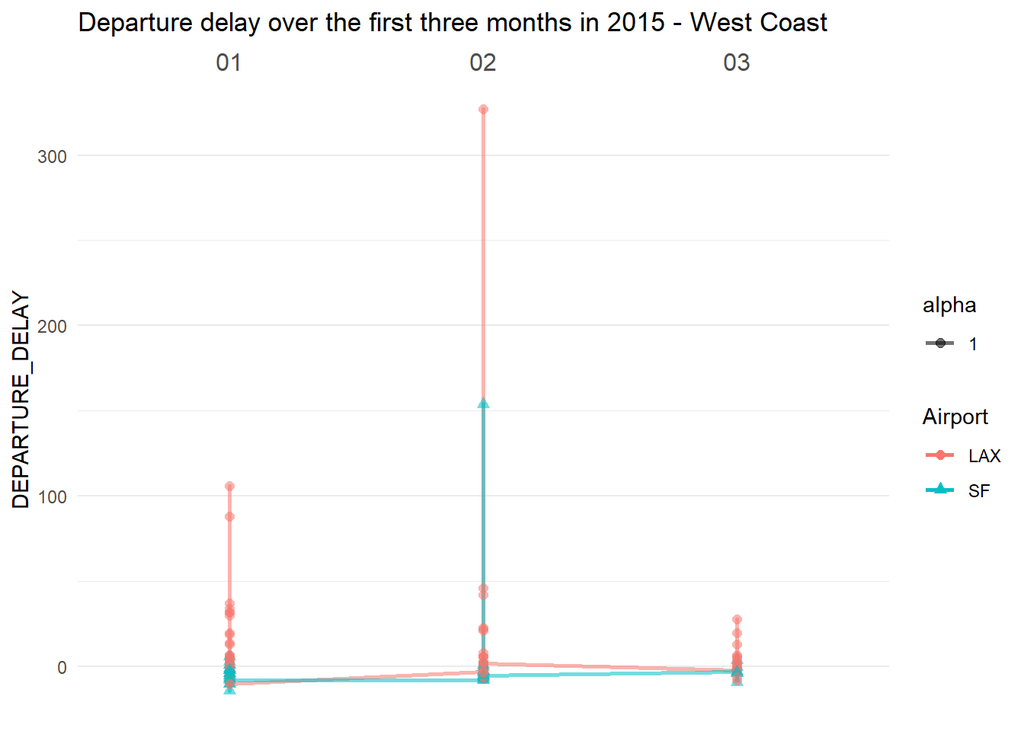

```r
b <- cvg %>% filter(ORIGIN_AIRPORT %in% c('LAX','SFO'))

ggplot(b,aes(x=dm,y=DEPARTURE_DELAY,group=ORIGIN_AIRPORT, shape = ORIGIN_AIRPORT, color = ORIGIN_AIRPORT)) +
  geom_line(aes(color=ORIGIN_AIRPORT,alpha=1),size=1) +
  geom_point(aes(color=ORIGIN_AIRPORT,alpha=1),size=2) +
  labs(
    title= "Departure delay over the first three months in 2015 - West Coast")+
  scale_x_discrete(position = "top") +
  theme_bw() +
  theme(legend.position = "right") +
  theme(panel.border     = element_blank()) +
  #theme(axis.title.y     = element_blank()) +
  #theme(axis.text.y      = element_blank()) +
  #theme(panel.grid.major.y = element_blank()) +
  #theme(panel.grid.minor.y = element_blank()) +
  theme(axis.title.x     = element_blank()) +
  theme(panel.grid.major.x = element_blank()) +
  theme(axis.text.x.top      = element_text(size=12)) +
  theme(axis.ticks       = element_blank())+
  scale_colour_discrete(name  = "Airport",labels = c("LAX", "SF")) +
  scale_shape_discrete(name  = "Airport",labels = c("LAX", "SF"))
```

- There are more delays in LAX than they are in San Francisco. The peak of amount of delays is in February (over 300 in time unit). Individually, there are more data points of delay in Jan than in February. In conclusion, Jan and Feb account for high departure delay

  Midwest

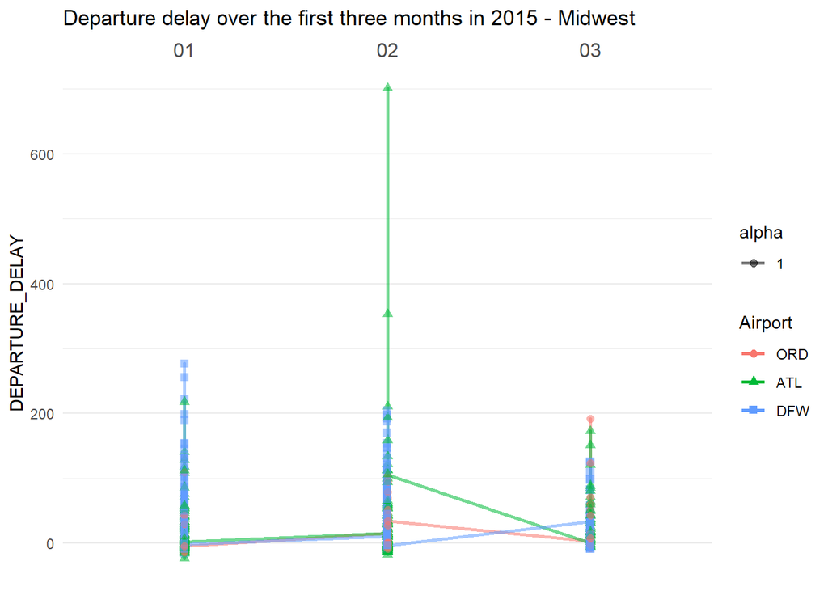

```r
m <- cvg %>% filter(ORIGIN_AIRPORT %in% c('ORD','ATL','DFW')) %>% filter(DEPARTURE_DELAY != "NA")

ggplot(m,aes(x=dm,y=DEPARTURE_DELAY,group=ORIGIN_AIRPORT,shape = ORIGIN_AIRPORT, color = ORIGIN_AIRPORT)) +
  geom_line(aes(color=ORIGIN_AIRPORT,alpha=1),size=1) +
  geom_point(aes(color=ORIGIN_AIRPORT,alpha=1),size=2) +
  labs(
    title= "Departure delay over the first three months in 2015 - Midwest")+
  scale_x_discrete(position = "top") +
  theme_bw() +
  theme(legend.position = "right") +
  theme(panel.border     = element_blank()) +
  #theme(axis.title.y     = element_blank()) +
  #theme(axis.text.y      = element_blank()) +
  #theme(panel.grid.major.y = element_blank()) +
  #theme(panel.grid.minor.y = element_blank()) +
  theme(axis.title.x     = element_blank()) +
  theme(panel.grid.major.x = element_blank()) +
  theme(axis.text.x.top      = element_text(size=12)) +
  theme(axis.ticks       = element_blank()) +   #delete
  scale_colour_discrete(name  = "Airport",labels = c("ORD", "ATL","DFW")) +
  scale_shape_discrete(name  = "Airport",labels = c("ORD", "ATL","DFW"))
```

East coast

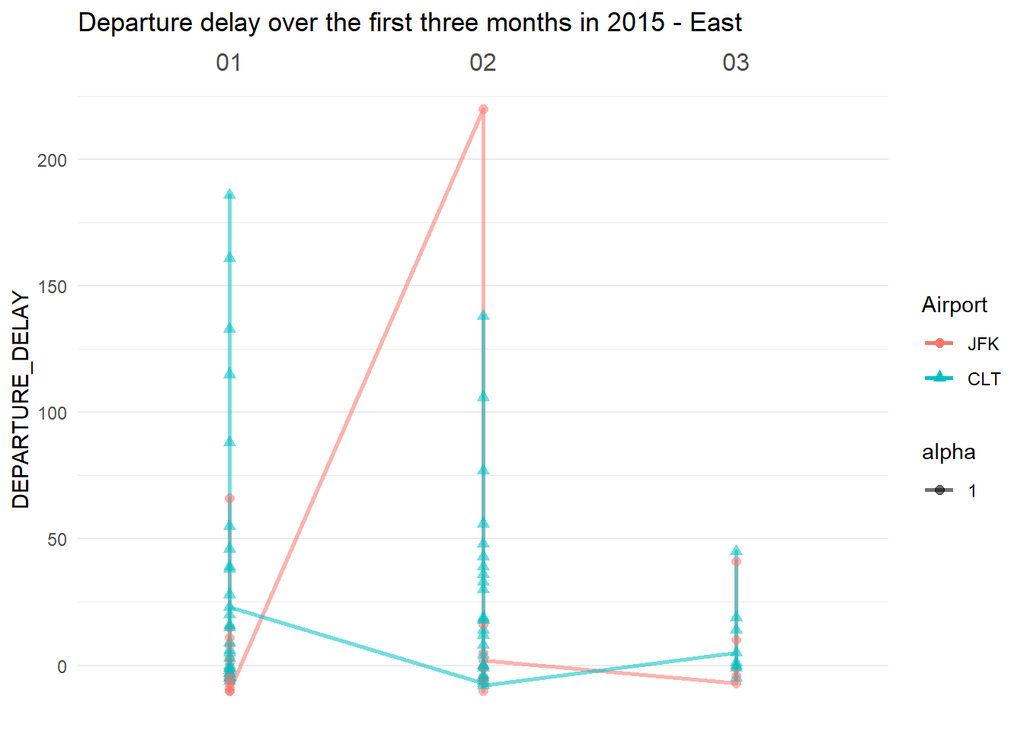

```r
e <- cvg %>% filter(ORIGIN_AIRPORT %in% c('JFK','CLT')) %>% filter(DEPARTURE_DELAY != "NA")
ggplot(e,aes(x=dm,y=DEPARTURE_DELAY,group=ORIGIN_AIRPORT,shape = ORIGIN_AIRPORT, color = ORIGIN_AIRPORT)) +
  geom_line(aes(color=ORIGIN_AIRPORT,alpha=1),size=1) +
  geom_point(aes(color=ORIGIN_AIRPORT,alpha=1),size=2) +
  labs(
    title= "Departure delay over the first three months in 2015 - East")+
  scale_x_discrete(position = "top") +
  theme_bw() +
  theme(legend.position = "right") +
  theme(panel.border     = element_blank()) +
  #theme(axis.title.y     = element_blank()) +
  #theme(axis.text.y      = element_blank()) +
  #theme(panel.grid.major.y = element_blank()) +
  #theme(panel.grid.minor.y = element_blank()) +
  theme(axis.title.x     = element_blank()) +
  theme(panel.grid.major.x = element_blank()) +
  theme(axis.text.x.top      = element_text(size=12)) +
  theme(axis.ticks       = element_blank()) +   #delete
  scale_colour_discrete(name  = "Airport",labels = c("JFK","CLT")) +
  scale_shape_discrete(name  = "Airport",labels = c("JFK","CLT"))
```

## Question 2:

Which airline has the most delay in Major US Airports by month?

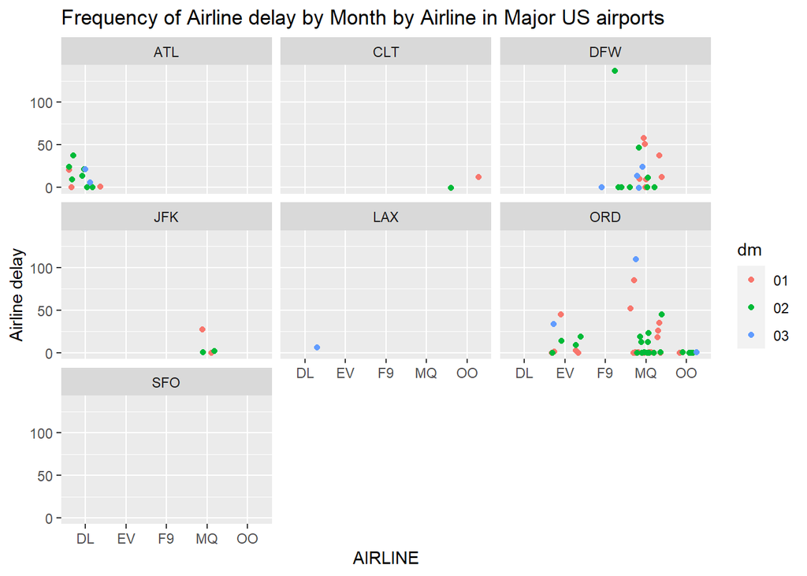

```r
region <- cvg %>% filter(ORIGIN_AIRPORT == c('LAX','SFO','ORD','JFK','DFW','ATL','CLT'))
ggplot(region, aes(y = AIRLINE_DELAY, x = AIRLINE, color = dm)) + geom_jitter() + facet_wrap(~ORIGIN_AIRPORT) + ylab("Airline delay") + xlab("AIRLINE") + ggtitle("Frequency of Airline delay by Month by Airline in Major US airports")
```

- With major international airports in different region, the airline MQ has high airline delay both in DFW and ORD, following is DL and EV

## Question 3: Which month CVG has most arrival delay to major airports including ORD, LAX, SFO, ATL, DFW, JFK

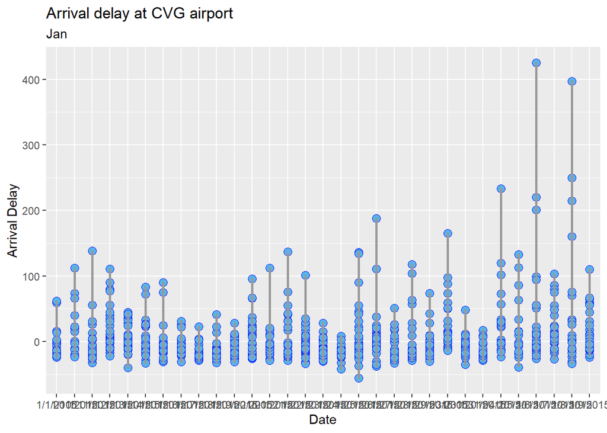

```r
jan <- cvg %>% filter(dm == "01") %>% filter(DESTINATION_AIRPORT %in% c('ORD','LAX','SFO','JFK','DFW','ATL'))
ggplot(jan, aes(x = FLIGHT_DATE, y = ARRIVAL_DELAY)) +
  geom_point(shape=21,color='blue',fill='#56B4E9',size=3)+
  geom_line(color='grey60',size=1)+
  labs(title = "Arrival delay at CVG airport",
       subtitle = "Jan",
       x = "Date", y = "Arrival Delay")
```

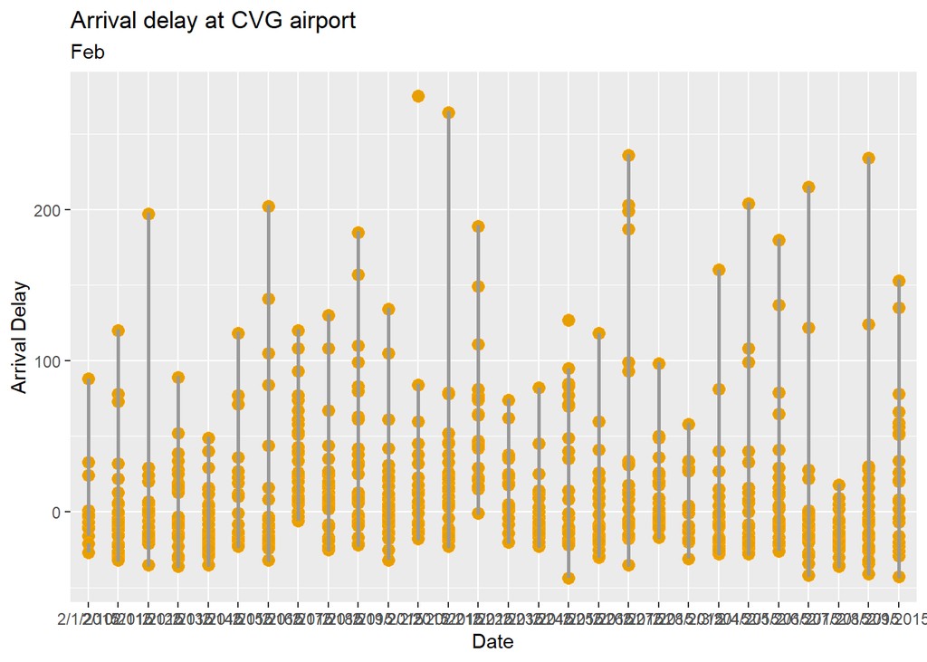

```r
feb <- cvg %>% filter(dm == "02") %>% filter(DESTINATION_AIRPORT %in% c('ORD','LAX','SFO','JFK','DFW','ATL'))
ggplot(feb, aes(x = FLIGHT_DATE, y = ARRIVAL_DELAY)) +
  geom_point(shape=21,color='orange',fill='#E69F00',size=3)+
  geom_line(color='grey60',size=1)+
  labs(title = "Arrival delay at CVG airport",
       subtitle = "Feb",
       x = "Date", y = "Arrival Delay")
```

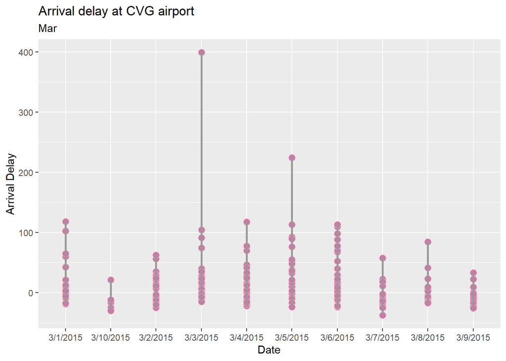

```r
mar <- cvg %>% filter(dm == "03") %>% filter(DESTINATION_AIRPORT %in% c('ORD','LAX','SFO','JFK','DFW','ATL'))
ggplot(mar, aes(x = FLIGHT_DATE, y = ARRIVAL_DELAY)) +
  geom_point(shape=21,color='pink',fill='#CC79A7',size=3)+
  geom_line(color='grey60',size=1)+
  labs(title = "Arrival delay at CVG airport",
       subtitle = "Mar",
       x = "Date", y = "Arrival Delay")
```

# College data set

```r
college <- read.csv('college.csv')
```

## Question 1:

California is an interesting state and I wonder what is the median tuition fee for all colleges in the state of California since living and studying the state is expensive

First, I would like to take a general look on median tuition fee in each region across the US

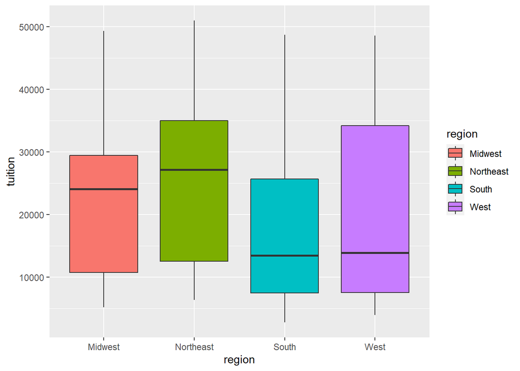

```r
ggplot(college, aes(x = region, y = tuition, fill = region)) + geom_boxplot()
```

  Then I filter down state = California to see the statistic for later comparision

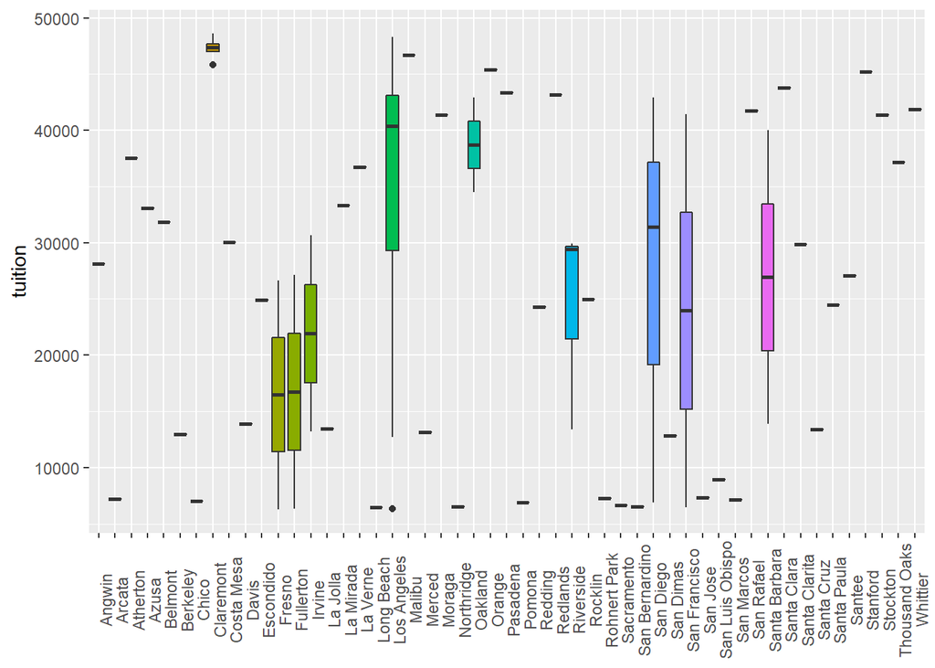

```r
ca <- college %>% filter(state == "CA")

ggplot(ca, aes(x = city, y = tuition, fill = city)) + geom_boxplot() + theme(legend.position = "none")+
  theme(axis.title.x = element_blank()) +
  theme(axis.text.x = element_text(angle = 90))
```

- Generally, high and low tuition are equally distrbuted among colleges in different cities in California. There are several cities varied in tuition fee. Overall, the median tuition fee is over from $20000-$30000 and above in many cities in California

I would also like to see California compared to other states in the west

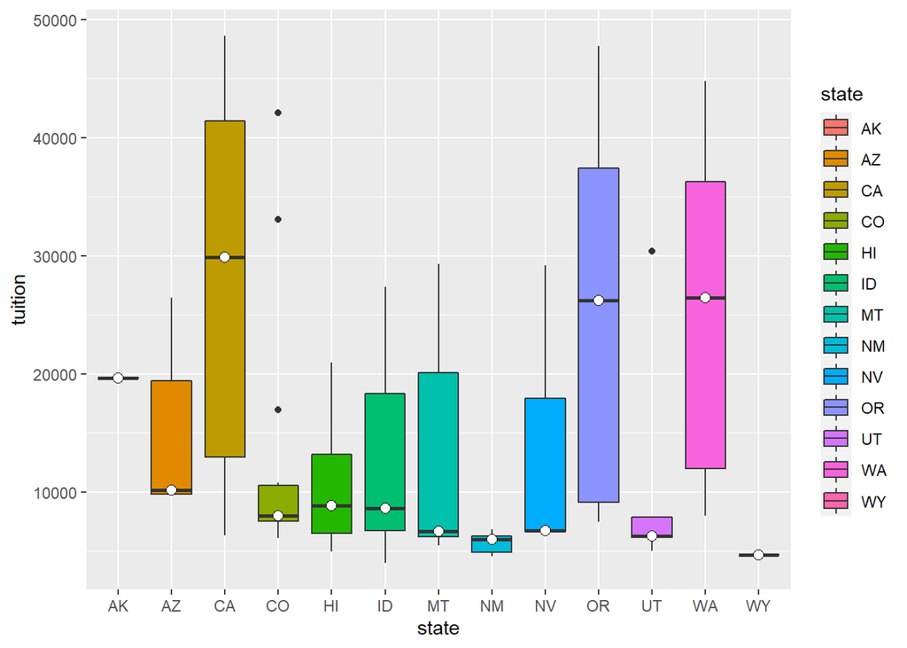

```r
w <- college %>% filter(region == 'West')

ggplot(w,aes(x = state,y = tuition,fill=state))+
  geom_boxplot()+
  stat_summary(fun = median,geom = "point",fill="white",size=2.5,shape=21)
```

- Like I have mentioned above for the median tuition fee for California. This graph has depicted sucessfully. Compared to other states in West area, California’s median tuition is the highest ($30000). The second highest are Oregon and Washington. The rest are mostly below $10000 for median tuition

## Question 2:

OHio curious ;) Since living in Cincinnati, OH. I am curious about admission rate, SAT requirement, tuition fee, and median debt in colleges in major cities in OH

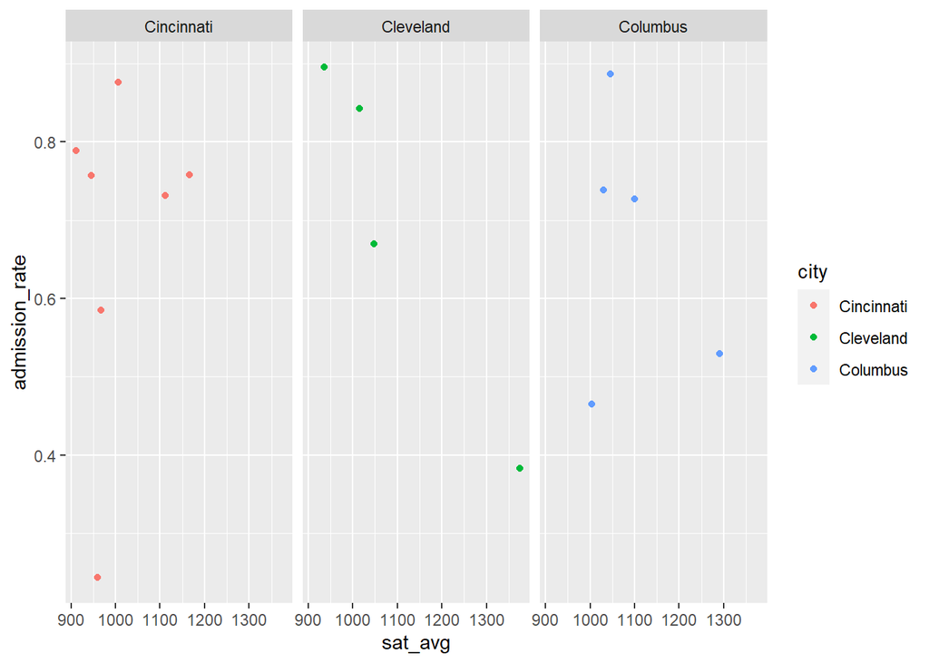

```r
library(RColorBrewer)
oh <- college %>% filter(state == "OH") %>% filter(city %in% c('Cincinnati','Columbus','Cleveland'))

ggplot(oh, aes(x = sat_avg, y = admission_rate, col = city)) + geom_jitter() + facet_wrap(~city)
```

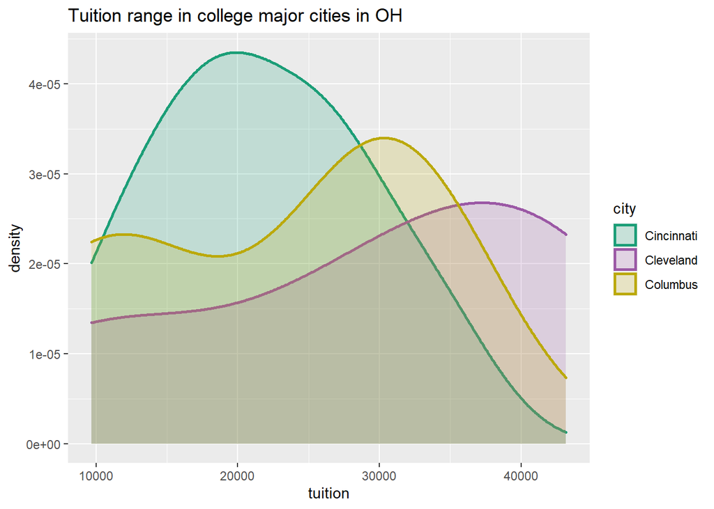

```r
ggplot(oh,aes(x=tuition,color=city,fill=city))+ geom_density(alpha = 0.2,size=1,linetype="solid")+
  scale_color_manual(values =colorRampPalette(brewer.pal(8,"Dark2"))(4))+
  scale_fill_manual(values =colorRampPalette(brewer.pal(8,"Dark2"))(4))+
  ggtitle("Tuition range in college major cities in OH")
```

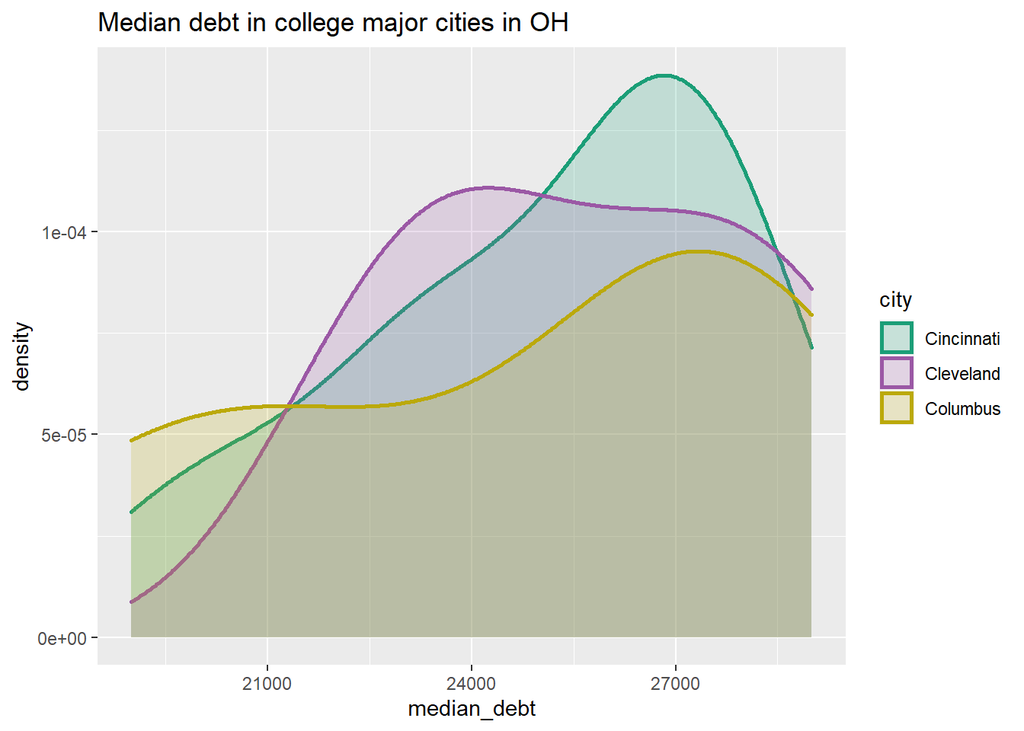

```r
ggplot(oh,aes(x=median_debt,color=city,fill=city))+ geom_density(alpha = 0.2,size=1,linetype="solid")+
  scale_color_manual(values =colorRampPalette(brewer.pal(8,"Dark2"))(4))+
  scale_fill_manual(values =colorRampPalette(brewer.pal(8,"Dark2"))(4))+
  ggtitle("Median debt in college major cities in OH")
```

- First graph : Cincinnati has high admission rate but low average SAT. Admission rate for Cleveland is the same like Cincinnati but there is a school requires high SAT (higest among other two cities). Columbus’s admission rate is average with average SAT score
- Second graph : Most colleges in Cincinnati has tuition around ($15000-$30000) while colleges in Columbus and Cleveland are mostly above $20000
- Third graph : Although tuition fee in most colleges in Cincinnati are low compared to that in Columbus and Cleveland, Cincinnati has high density of debt (mostly above $24000) than the other two cities.

## Question 3:

Public and Private college performance

Life is full of curiousity :)), I want to know the median debt in Public and Private colleges in the 4 regions. As to my knowing that it is more expensive to attend Private colleges

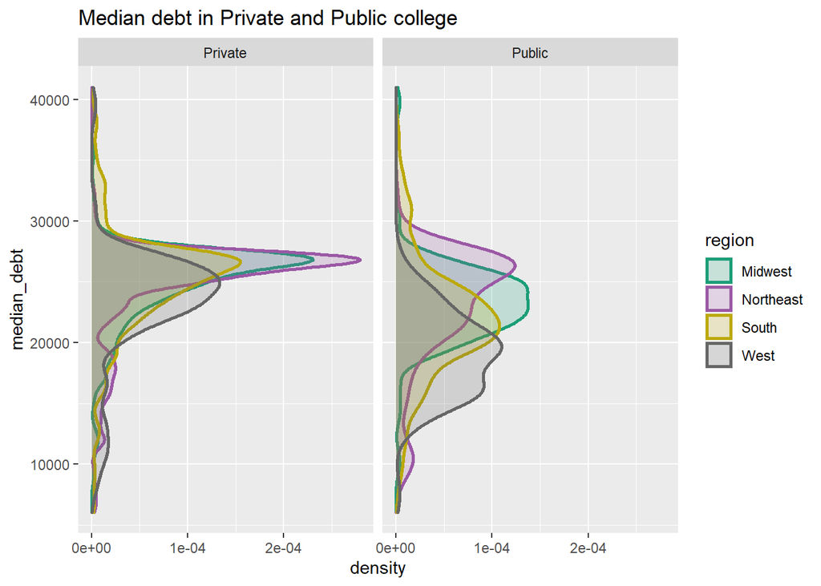

```r
ggplot(college,aes(y=median_debt,color=region,fill=region))+ geom_density(alpha = 0.2,size=1,linetype="solid")+
  scale_color_manual(values =colorRampPalette(brewer.pal(8,"Dark2"))(4))+
  scale_fill_manual(values =colorRampPalette(brewer.pal(8,"Dark2"))(4))+
  ggtitle("Median debt in Private and Public college")+
  facet_wrap(~control)
```

- Generally, the median debt for private and public colleges are distributed around $20000 and $30000 for all region in the US. The median debt for private colleges accounted for almost 90% in range of $20000 and $30000. Public colleges median debt makes up of 70% median debt of $20000-$30000 and about 20% below $20000

I then dwell into the average faculty salary and tuition fee in big major cities in the US, also to compare Cincinnati performance

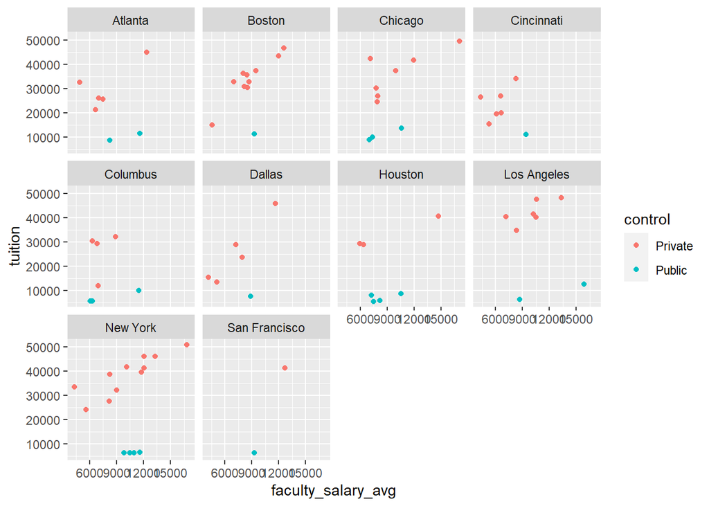

```r
c <- college %>% filter(city %in% c('Chicago','Los Angeles','San Francisco','New York','Boston','Dallas','Houston','Atlanta','Columbus','Cincinnati'))

ggplot(c, aes(y=tuition, x = faculty_salary_avg, color = control)) +
  geom_point() + facet_wrap(~city)
```